# Manifolds no lineales

*Aprendizaje máquina II*

*Curso 2023-2024*

Authors:

- Rubén Castillo Carrasco

- Manuel Rubio Martínez

```python
%matplotlib inline
```

# Reducción de dimensionalidad de Swissroll y Sphere

1. Aplica los *spectral embedding, LLE, Isomap y MDS* a los conjuntos de datos "rollo suizo" y "esfera" con n_neighbours=12 y compara los resultados obtenidos.
2. Aplica las diferentes variantes de LLE implementadas en sklearn con estos 2 conjuntos de datos.
3. Contesta a las preguntas.

## 1. Embedding con los 4 métodos.

```
Computing MDS embedding
```

```
<function matplotlib.pyplot.show(close=None, block=None)>
```

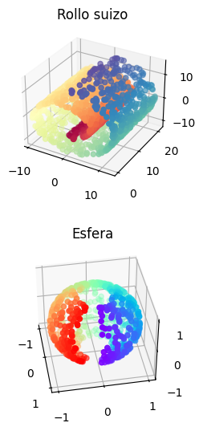

```python
from sklearn.manifold import LocallyLinearEmbedding,SpectralEmbedding,Isomap,MDS
import matplotlib.pyplot as plt
from sklearn.metrics.pairwise import manhattan_distances, euclidean_distances
from mpl_toolkits.mplot3d import Axes3D
from sklearn.utils import check_random_state
from sklearn import manifold, datasets

import numpy as np
Axes3D

# ----------------------------------------------------------------------
# Swiss roll

X1, color = datasets.make_swiss_roll(n_samples=1500, random_state=10)

# ----------------------------------------------------------------------
# Sphere

n_samples = 1000

# Create our sphere.
random_state = check_random_state(0)
p = random_state.rand(n_samples) * (2 * np.pi - 0.55)
t = random_state.rand(n_samples) * np.pi

# Sever the poles from the sphere.
indices = (t < (np.pi - (np.pi / 8))) & (t > ((np.pi / 8)))
colors = p[indices]
x, y, z = (
    np.sin(t[indices]) * np.cos(p[indices]),
    np.sin(t[indices]) * np.sin(p[indices]),
    np.cos(t[indices]),
)

X2 = np.array([x, y, z]).T


# MDS of the swiss roll

print("Computing MDS embedding")



# -----------------------------------------------------------------------

# Plot results

fig = plt.figure(figsize=(15, 13))
ax = fig.add_subplot(251, projection="3d")
ax.scatter(X1[:, 0], X1[:, 1], X1[:, 2], c=color, cmap=plt.cm.Spectral)
ax.set_title("Rollo suizo")







ax = fig.add_subplot(151, projection="3d")
ax.scatter(x, y, z, c=p[indices], cmap=plt.cm.rainbow)
ax.view_init(40, -10)
ax.set_title("Esfera")







plt.show
```

```
Computing Spectral embedding ()
```

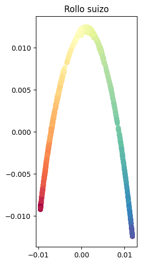

```python
# Locally linear embedding of the swiss roll

print("Computing Spectral embedding ()")



SE=SpectralEmbedding(n_components=2, affinity='nearest_neighbors', n_neighbors=12)
X1_embedding=SE.fit_transform(X1)
fig = plt.figure(figsize=(15, 13))
ax = fig.add_subplot(251)
ax.scatter(X1_embedding[:, 0], X1_embedding[:, 1], c=color, cmap=plt.cm.Spectral)
ax.set_title("Rollo suizo")


# ----------------------------------------------------------------------
```

Este es la peor representación, aunque si que separa bien el rollo

```
Computing LLE embedding
```

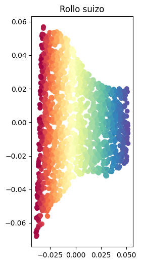

```python
# Locally linear embedding of the swiss roll

print("Computing LLE embedding")
lle=LocallyLinearEmbedding(n_components=2, random_state=10, n_neighbors=12)
X1_embedding=lle.fit_transform(X1)
fig = plt.figure(figsize=(15, 13))
ax = fig.add_subplot(251)
ax.scatter(X1_embedding[:, 0], X1_embedding[:, 1], c=color, cmap=plt.cm.Spectral)
ax.set_title("Rollo suizo")

# ----------------------------------------------------------------------
```

```
Computing Isomap embedding
```

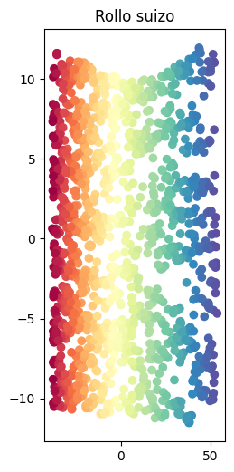

```python
# Isomap of the swiss roll

print("Computing Isomap embedding")

isomap = Isomap(n_neighbors=12, n_components=2)

embedded_points = isomap.fit_transform(X1)

fig = plt.figure(figsize=(15, 13))
ax = fig.add_subplot(251)
ax.scatter(embedded_points[:, 0], embedded_points[:, 1], c=color, cmap=plt.cm.Spectral)
ax.set_title("Rollo suizo")


# ----------------------------------------------------------------------
```

```
Computing MDS embedding
```

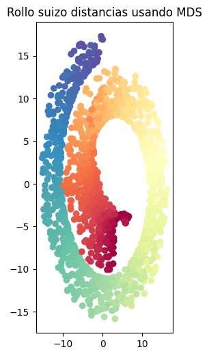

```python
# MDS of the swiss roll

print("Computing MDS embedding")

mds = MDS(n_components=2)
embedded_points = mds.fit_transform(X1)



fig = plt.figure(figsize=(15, 13))
ax = fig.add_subplot(251)
ax.scatter(embedded_points[:, 0], embedded_points[:, 1], c=color, cmap=plt.cm.Spectral)
ax.set_title("Rollo suizo distancias usando MDS")
```

Es muy lento, no tiene en cuenta la geometría de la figura, y calcula las distancias elemento a elemento

## Esfera

```
Computing Spectral embedding ()
```

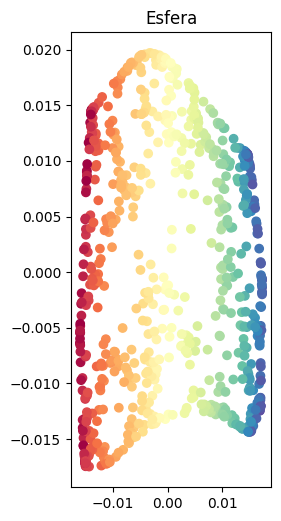

```python
# Locally linear embedding of the swiss roll

print("Computing Spectral embedding ()")



SE=SpectralEmbedding(n_components=2, affinity='nearest_neighbors', n_neighbors=12)
X1_embedding=SE.fit_transform(X2)
fig = plt.figure(figsize=(15, 13))
ax = fig.add_subplot(251)
ax.scatter(X1_embedding[:, 0], X1_embedding[:, 1], c=colors, cmap=plt.cm.Spectral)
ax.set_title("Esfera")


# ----------------------------------------------------------------------
```

```
Computing LLE embedding
```

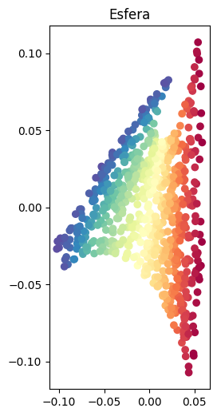

```python
# Locally linear embedding of the swiss roll

print("Computing LLE embedding")
lle=LocallyLinearEmbedding(n_components=2, random_state=10, n_neighbors=12)
X1_embedding=lle.fit_transform(X2)
fig = plt.figure(figsize=(15, 13))
ax = fig.add_subplot(251)
ax.scatter(X1_embedding[:, 0], X1_embedding[:, 1], c=colors, cmap=plt.cm.Spectral)
ax.set_title("Esfera")

# ----------------------------------------------------------------------
```

```
Computing Isomap embedding
```

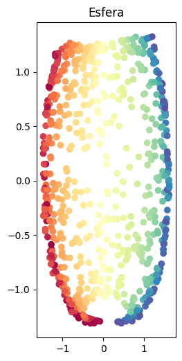

```python
# Isomap of the swiss roll

print("Computing Isomap embedding")

isomap = Isomap(n_neighbors=12, n_components=2)

embedded_points = isomap.fit_transform(X2)

fig = plt.figure(figsize=(15, 13))
ax = fig.add_subplot(251)
ax.scatter(embedded_points[:, 0], embedded_points[:, 1], c=colors, cmap=plt.cm.Spectral)
ax.set_title("Esfera")


# ----------------------------------------------------------------------
```

```
Computing MDS embedding
```

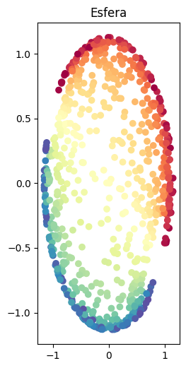

```python
# MDS of the swiss roll

print("Computing MDS embedding")

mds = MDS(n_components=2)
embedded_points = mds.fit_transform(X2)



fig = plt.figure(figsize=(15, 13))
ax = fig.add_subplot(251)
ax.scatter(embedded_points[:, 0], embedded_points[:, 1], c=colors, cmap=plt.cm.Spectral)
ax.set_title("Esfera")
```

## 2. Variantes de LLE.

Se prueban cuatro variantes del LLE para la reducción de dimensionalidad no lineal. Entre los seleccionados, estos son la variante estandar (vista antes), el LTSA, Hessiano y Modificado.

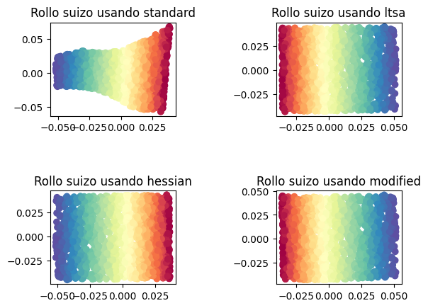

```python
from sklearn.manifold import LocallyLinearEmbedding

methods = ["standard", "ltsa", "hessian", "modified"]

fig, ax = plt.subplots(nrows=2,ncols=2)
plt.subplots_adjust(wspace=0.8, hspace=0.8)

for i,m in enumerate(methods):
    mod  = manifold.LocallyLinearEmbedding(
                n_neighbors=12, n_components=2, method=m, random_state=42)
    res = mod.fit_transform(X1)
    ax[i//2,i%2].scatter(res[:, 0], res[:, 1], c=color, cmap=plt.cm.Spectral)
    ax[i//2,i%2].set_title("Rollo suizo usando {}".format(m))


plt.show()
```

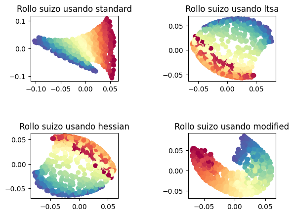

```python
methods = ["standard", "ltsa", "hessian", "modified"]

fig, ax = plt.subplots(nrows=2,ncols=2)
plt.subplots_adjust(wspace=0.8, hspace=0.8)

for i,m in enumerate(methods):
    mod  = manifold.LocallyLinearEmbedding(
                n_neighbors=12, n_components=2, method=m, random_state=42)
    res = mod.fit_transform(X2)
    ax[i//2,i%2].scatter(res[:, 0], res[:, 1], c=colors, cmap=plt.cm.Spectral)
    ax[i//2,i%2].set_title("Rollo suizo usando {}".format(m))


plt.show()
```

## 3. Responde a las preguntas.

Comenta los siguientes puntos:

```
 1)¿Qué algoritmo de manifold NO LINEAL realiza una representación más próxima a la real?
```

Isomap en el caso del rollo suizo, y para la esfera el espectral embeding, pero al ser lineal, la no lineal mejor sigue siendo Isomap.

```
 2)¿Por qué la representación de MDS es tan diferente a la del resto?
```

Porque calcula todas las distancias, y utiliza estas para representar las figuras. No preserva la forma original, ignorando el embeding en la representación de las figura. Además tarda bastante más que el resto al tener que hacer muchísimos más cálculos.

```
3) Modifica el número de vecinos y compara los resultados
```

Vamos a realizar un ejemplo con el rollo suizo utilizando Isomap:

```
Computing Isomap embedding
```

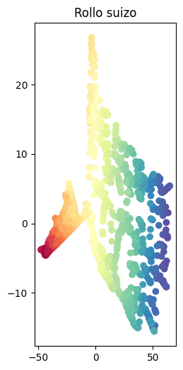

```python
# Isomap of the swiss roll

print("Computing Isomap embedding")

isomap = Isomap(n_neighbors=4, n_components=2)

embedded_points = isomap.fit_transform(X1)

fig = plt.figure(figsize=(15, 13))
ax = fig.add_subplot(251)
ax.scatter(embedded_points[:, 0], embedded_points[:, 1], c=color, cmap=plt.cm.Spectral)
ax.set_title("Rollo suizo")


# ----------------------------------------------------------------------
```

Si utilizamos un número muy pequeño de vecinos, altera mucho al forma y depende del muestreo que se haya hecho de los datos.

```
Computing Isomap embedding
```

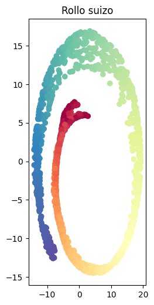

```python
# Isomap of the swiss roll

print("Computing Isomap embedding")

isomap = Isomap(n_neighbors=50, n_components=2)

embedded_points = isomap.fit_transform(X1)

fig = plt.figure(figsize=(15, 13))
ax = fig.add_subplot(251)
ax.scatter(embedded_points[:, 0], embedded_points[:, 1], c=color, cmap=plt.cm.Spectral)
ax.set_title("Rollo suizo")


# ----------------------------------------------------------------------
```

Si metemos un número muy alto de vecinos, puntos que no estén próximos directamente a la figura (los que están en otra capa del rollo) entrarán dentro del vecindario, entonces el embeding no representará bien la forma de banda plegada que tiene el rollo.

```
4) ¿Qué variante de LLE hace una reducción de dimensionalidad más próxima a la real?
```

Para el rollo suizo, tenemos que tanto LTSA como Hessian y Modiffied presentan mejores representaciones de la realidad frente a la estandard. En cambio, para el conjunto de datos de la esfera, las que mejor se aproximan podrían parecer la estandar y la modified, ya que en el resto se solapan algunos de los puntos que no están conectados.